# Collective Violence: Mob Formation of Lynchings

Ben Wallace

4/27/2021

## Introduction

> Lord you gave your only son to remedy a condition, but who knows but what the death of my only son might bring an end to lynching.

Mamie E. Bradley, mother of Emmett Till, *The Blood of Emmett Till*

The National Association for the Advancement of Colored People defines an incident as a lynching if (1) there is evidence that someone was killed, (2) the killing occurred illegally, (3) three or more people took part in the killing, and (4) the killers claimed to be serving justice or tradition (Project HAL 2004). This is rigid but fairly accurate criteria describing a significant portion of racial violence that occurred in the United States between the nineteenth and first half of the twentieth centuries. Estimates of the total death toll from lynchings range from as low as 2,522 (Soule 1992) to as high as 3,417 (Dray 2002). Even as researchers collect larger inventories about victims of lynchings and their perpetrators, it appears unlikely that the complete picture of racialized violence will ever be captured.

Sociologists have tested multiple hypotheses about the factors that made lynchings more likely to occur in geographic areas, ranging from racial competition (Blalock 1967), economic insecurity (Raper 1933; Hoyland & Sears 1940; Soule 1992), segregation (Cook 2018), historical links to slavery (Price et. al 2008), crops (Tolnay & Beck 1990, 1992), and attachment to political parties (Corzine, Creech, & Lin 1983; Reed, 1972; Tolnay, Beck and Massey 1989). Other studies have investigated different dimensions of lynchings such as their atrocity (Leader et al. 2007; Ritchey & Ruback 2018), relationship to law enforcement (Keil & Fito 2009), and publicity (Smångs 2017). Some have even contested historical conceptions of racialized violence to include lynching threats and averted incidents (Hagen et al. 2013).

Both sociological and historical studies have unearthed and refined several key truths about lynchings. First, a majority but not all lynchings in the United States occurred in the South. Second, racial minorities, especially Black Americans, were uniquely and disproportionately targeted by these killings. Finally, and most recently, scholars have discovered significantly more heterogeneity in the motivations behind lynchings depending on the region and publicity of the occurrences (Seguin & Rigby 2016).

Although there has been significant attention paid to lynchings for over a century, there lacks much empirical study on the sizes of mobs that enacted these killings. Although some have built the theoretical distinction between private and spectacle lynchings and how larger-scalelynchings are more violent (Smångs 2016), this simple binary is difficult to concretely define. In reality, there existed a wide variety of mob sizes that contributed to this legacy of violence. There also lacks research seeking to explain the mob size of lynchings with demographic information about victims such as race and gender as well as their alleged offense.

In this paper, after reviewing the history of lynching and sociological perspectives of mob formation, I will put historical understandings about private and spectacle lynchings to statistical review. Using an ordered logistic model, I demonstrate that Black lynching victims as well as those accused of murder and violations of the interracial sexual color line drew larger mob sizes in the United States. Even though lynching inventories are burdened by missing data, my results still affirm the lineage of historical analysis and black activism contesting lynchings as not only individual-driven incidents but also as a means of social control and collective identity construction, particularly in white racial ideologies such as white supremacy and interracial sexual paranoia.

## Background

#### History of Lynching

According to Busia (1988: 6-7), language is not “‘innocent’: It is ideologically and culturally bound, and it both expresses and conceals our realities.” Just as language can create art or call for justice, it is also tangled in societal notions of morality, justice, and hegemony. Applied to the case of lynchings, one can grasp much about the historical attitudes that sanctioned the practice by simply analyzing the term itself.

The term “lynching” is derived from the wealthy Virginian planter Charles Lynch who, during the American Revolution, spearheaded extrajudicial killings of loyalists to maintain ranks against the British commonwealth (Page 1901). This is derived from a vigilante justice tradition that can be traced back centuries, from medieval Europe (Pfeifer 2017) to the colonial origins of the United States. However, Lynch’s actions instilled a new form of mob violence in the American collective memory, one meant to control the public and cement a new form of patriot identity.

Mob violence has existed throughout American history, but these secretive lynchings arose most prominently during the nineteenth century in the western frontier states and included mostly white victims in areas with “weak state penetration” (Seguin & Rigby 2016: 5; Pfeifer 2011; Wells 1909). As the practice declined in the west during the late nineteenth century, it emerged in the South, mostly targeting African Americans and poor whites with “ceremonial brutality” (Smångs 2016). While private lynchings still occurred in the South, spectacle lynchings more effectively instilled fear in African American populations and reinforced a collective identity (Wright 1990; Subašić et al. 2008) of white supremacy. Historians and Black writers often point to the high-profile violence disproportionately enacted against Blacks and men. These individuals were frequently accused of the most heinous crimes, namely murder and rape (Frisken 2012). In particular, the severity of a rape indictment for Black men was twofold; not only were they charged with violating womanhood, but they also faced a growing white fear of interracial sex between white women and Black men (Smångs 2020).

#### From Polity to Economy: Perspectives on Lynching and Mob Formation

One of the most studied questions regarding ceremonial lynchings is “why did they occur?” Blalock (1967) introduced the power-threat hypothesis which posited that dominant groups use a variety of tactics, such as lynching, to control minority groups and ensure their continued access to resources and privilege. Studies testing the power-threat hypothesis have turned towards Census data to test whether higher concentrations or sizes of Black populations correlate with higher rates or incidents of lynchings, beginning with Raper (1933). For instance, Tolnay, Beck, and Massey (1989) investigated nearly 3,000 lynchings of Blacks in the period between 1889 and 1931 and did not observe an association between Black concentration and lynching rates. However, they later revised their study (1990, 1992) and found a statistically significant positive correlation between Black population size and lynching incidents. Similarly, Corzine et. al (1983) successfully tested a nonlinear relationship between these Black population concentrations and lynching occurrences; in other words, the number of lynchings appeared to increase at the lowest and highest concentrations of Black populations.

Others have extended the power-threat framework to other competitions over power, namely the electoral system. For example, Southern counties with higher support for the Populist and Republican parties had fewer instances of lynching relative to Democratic strongholds (Beck, Massey, & Tolnay 1989; Soule 1992; Tolnay & Beck 1995; Corzine, Creech, & Lin 1983; Reed, 1972). Even whites that voted against Democratic candidates were seen as “racial traitors” (Bartley 1990; Kantrowitz 2000) and faced scrutiny or threats within their communities. As a result, whites’ policing of partisanship and the race line, including lynching, represented a response to a perceived threat by racial minorities. When white conservatives enacted laws that segregated (Cook et. al 2018) and disenfranchised Black communities, the perceived threat of racial minorities reduced, and consequently, white mobs lynched fewer people (Soule 1992; Corzine, Creech, and Corzine 1983).

Built on the framework of the power-threat hypothesis, sociologists have constructed the economic-insecurity hypothesis (Hovland & Sears 1940; Raper 1933) which argues that lynchings enacted by white parties and mobs are driven by “aggressive response to economic frustration or a deliberate attempt to improve the economic position of whites relative to Blacks” (Cook 2018, 7). Past studies have linked stagnant cotton prices and inflation with spikes in racial violence, particularly in the Deep South (Tolnay & Beck 1990, 1992). Others have connected interracial competition over farmland, jobs, and other economic resources with higher rates of antagonism towards Blacks (Blalock 1967; Bonacich 1972; Wright 1986), which resulted in lynchings by white mobs.

#### Shortcomings of Sociological Perspectives in Lynching Scholarship

The power-threat and economic-insecurity hypotheses offer convincing evidence that intergroup conflict in the politic and the economy contributed to lynchings in the South. However, both neglect several key tenants of the practice’s history. First, their theoretical frameworks do not acknowledge the bifurcation of lynchings into private and spectacle occurrences. One cannot assume that these two forms of mob violence are influenced by the same social forces or at least in the same manner. Second, the two hypotheses neglect or insufficiently address the ways in which white racial ideologies built on white supremacy and fears of interracial sex contributed to these killings. For instance, Blalock’s (1967) analysis of lynchings refers to prejudice and discrimination at the individual level but ignores the racial hierarchy that emboldens mass racial violence. Racial violence was not only a tool of aggression; it also was used to intimidate Black voters and reestablish white control of Southern governments. Later research such as Tolnay and Beck (1989) acknowledge white supremacy’s existence but did not attempt to operationalize this force when investigating the power threat hypothesis and connections between lynchings and cotton agriculture (1992). For example, their choice to exclude counties with populations of less than five percent black from their analysis of the power threat hypothesis because “it is unlikely that whites [in these cases] would have feared blacks obtaining political power” ignores the irrational fears and perceptions brewed by racial ideologies that lead to racial violence. Finally, past theoretical frameworks on lynchings are based on assumptions and tested purely on Southern lynchings, thus excluding any regional heterogeneity (Seguin 2016) in mob violence.

To holistically address the social forces that spurred mob violence, empirical studies must acknowledge over a century of documentation, compiled mostly by the Black press, activists, and historians, that points to white racial ideologies fueling spectacle lynchings. Thus, the central research question of this study is: how can I measure the extent to which white supremacy and fears of interracial sex contribute to spectacle lynchings? Combining past historical analysis with sociological theory, I hypothesize the following:

**Hypothesis 1**: The lynching of Black individuals draws larger mob sizes than those of whites.

**Hypothesis 2**: The lynching of men draws larger mob sizes than those of women.

**Hypothesis 3:** Lynching victims accused of murder or sexual crimes draw larger mob sizes than other alleged offenses.

## Data and Methods

#### Data and Variables from Tolnay-Beck and Seguin-Rigby Inventories

Researchers have collected data on lynching for over a century (NAACP 1919). In this study, I will analyze data from two of the most comprehensive inventories created over this period: Tolnay and Beck (1995) as well as Seguin and Rigby (2016). The former dataset contains entries for 4,928 lynching victims in 16 states, the majority of which are in the Census-defined Southeastern United States. The Seguin and Rigby inventory contains an additional 1,328 lynching victims from 36 states. Both inventories include information about the victim including their gender, race, name, the alleged offense that led to their lynching, method of lynching, location, and date of death.

In my analysis, I construct mob size as a dependent variable. Each victim in the Tolnay-Beck inventory is coded a number zero through six to identify the size of the mob responsible for their lynching. In cases assigned a zero, this indicates an unreported or ambiguous mob size. A number one through six corresponds to an increasing scale representing the number of perpetrators in the lynching: less than 10, 10 to 49, 50 to 99, 100 to 499, 500 to 999, and 1000 or more.

Since the Seguin-Rigby inventory does not include mob size codes, I use each entry’s confirming newspaper document to assign it a code in the Tolnay-Beck scale. When a range such as “75-100” was reported, I take the average of these two ranges. Other lynching reports in the Seguin-Rigby inventory included terms such as “party of men” or “posse,” and in these cases a mob size code is assigned based on the Tolnay-Beck codebook (Table A1).

The entries from both inventories that have undeterminable mob sizes are excluded from analysis. Unfortunately, 34% of the Tolnay-Beck inventory and 48% of the Seguin-Rigby inventory falls into this category. T-tests and Chi-Square tests of independence reveal that these missing data are not randomly distributed (Table A2). They are in whiter areas, the victims are more likely to be those accused of minor offenses, unknown offenses, or miscellaneous cases. They also disproportionately include lynchings in the western region of the country. I expect these findings to lead to an overestimation of the mob size for these categories since unreported lynchings can be assumed to be smaller scale than large spectacle ones, where there is likely more media attention and documentation. Thus, any significant result finding that the lynchings of Blacks or those accused of sexual offenses or murder have larger mob sizes is likely a conservative approximation.

Finally, I construct several control variables using the two inventories. The first corresponds to the Census-defined region in which the lynching occurred to account for variation due to the heterogeneity of lynching practices across regions (Seguin & Rigby 2016). I also account for variation in mob size over time by including time fixed effects based on the year in which the lynching occurred.

#### Regional Demographic Information as Control Variables

After merging the two inventories, I add data from the 1920 Census data as well as the Democratic presidential candidate’s share of the two-party vote to each lynching victim’s entry based on the county in which the mob formed. This and the location where the lynching occurred is nearly always the same but epistemically different since the analysis is focused on mob formation rather than the lynching itself.

Previous analysis of the lynching era has noted that demographic information and support for political parties in the South are relatively constant over the period following Reconstruction and the Jim Crow (Soule 1992). For instance, each former-Confederate state supported the Democratic presidential candidate in the forty years between 1880 and 1920 (“Historical Presidential Elections” 2006). For this reason, I assume that there is an insignificant error produced from using election data from this period. However, this logic is less robust when applied to non-southern states.

From the 1920 Census, I create several control variables including an estimation of each county’s population that is nonwhite, rural. To account for nonlinear effects, I also include quadratic terms for each of these variables as well as the Democrat’s share of the two-party vote. Finally, I take the population density of each county. Since this variable is heavily skewed-right, I only include its natural logarithm in the analysis.

#### Ordered Logistic Regression

Because the dependent variable mob size is a factor with consequential order, I use ordered logistic regression to estimate if variation in mob size is significantly explained by race, gender, and the alleged offense. After controlling for temporal and spatial variation as well as demographic information such as nonwhite and rural concentration, the illiteracy rate among adult whites, and the natural logarithm of population density, the model can be written in the following form:

$logit(\rho) = log\frac{P(\rho\leq\rho_{j})}{P(\rho>\rho_j)}=\beta_0-\eta_1x_1-...-\eta_px_p$

Where $\rho$ is the true categorical mob size of an lynching event, $\beta_0$ is a constant intercept, and the terms $\eta_1x_1$ to $\eta_px_p$ represent all of effects of the independent and control variables on the odds of any given $\rho$ moving up a category.

## Results

**Table 1**

|  | *Dependent variable:* |
| --- | --- |
|  | Mob Size |
| Sexual Offense | 3.155*** (2.863, 3.447) |
| Murder | 4.032*** (3.745, 4.319) |
| Unknown Offense | 2.079*** (1.752, 2.406) |
| Miscellaneous | 0.592*** (0.221, 0.963) |
| Minor Offense | 1.375*** (1.068, 1.682) |
| White | 0.701*** (0.539, 0.863) |
| Mexican | 3.222*** (2.493, 3.950) |
| Asian | 0.222 (-0.889, 1.333) |
| American Indian | 0.791 (-0.267, 1.849) |
| Male | 1.199*** (0.820, 1.578) |
| Unknown Gender | 3.234*** (2.217, 4.251) |
| West | 2.103*** (1.716, 2.489) |
| Midwest | 2.049*** (1.752, 2.347) |
| Northeast | 1.564 (-0.447, 3.576) |
| Population Density | 1.004*** (0.923, 1.086) |
| Percent Nonwhite | 0.567 (-0.423, 1.556) |
| Percent Nonwhite Squared | 1.136 (-0.307, 2.579) |
| Percent Rural | 2.016*** (0.832, 3.200) |
| Percent Population Rural Squared | 0.595 (-0.284, 1.475) |
| Percent White Adults Illiterate | 0.735 (-0.633, 2.102) |
| Percent White Adults Illiterate Squared | 0.981 (-0.476, 2.437) |
| Democratic Vote | 0.914 (-0.234, 2.062) |
| Democratic Vote Squared | 1.232** (0.158, 2.306) |
| Observations | 3,761 |
| *Note:* | p<0.1; p<0.05; p<0.01 |

There are also multiple significant coefficients in the racial categories. However, there are not enough observations of Mexican, Asian, or American Indian individuals for their conclusions to be generalizable. Still, I can conclude that the odds that a white lynching victim’s mob size increases one category is approximately 0.7 times lower than for Black victims, all other variables held constant. This result is significant at p < 0.01.

Gender, the last focal independent variable, likewise has only enough observations of males and females to be generalizable in these cases. There were only 14 individuals with an unknown gender in the dataset. From the ordered logistic model, I find that male lynching victims are nearly 1.2 times or 20% more likely to increase one mob size category than females after keeping all other variables constant.

I find the control variable for region to be significant in the cases in the Midwest and Western regions of the country. They both have coefficients of approximately two, meaning that a lynching case in the Midwest or West is about two times or 100% more likely to increase one larger mob size category than a Southern lynching, all else held constant. However, a majority of Western lynchings and nearly half of Midwestern lynchings had unreported mob sizes (Figure A4), which I assume to be smaller-scale since spectacle lynchings draw more media attention and documentation. Because of this, conclusions about regional differences in mob sizes are not robust. If anything, the model likely overestimates the true mob size of a Western or Midwestern lynching.

## Discussion

The findings in this paper demonstrate convincing evidence for all three hypotheses: that Black individuals, males, and those accused of murder and sexual crimes were more likely to be killed in spectacle lynchings as opposed to private and vigilante ones. Coupled with past research that has found large-scale mob killings to be more atrocious (Leader et al. 2007), my results suggest that Black and male individuals faced far more violent lynchings than other racial and gender groups.

These results also affirm historical analysis of the different types of lynchings. For example, multiple historians have categorized white lynchings as private affairs, enacted against those in violation of “male chivalry [and] family honor” (Brundage 1993; 90) or other small-scale disagreements. In contrast, the lynchings of Black people were depicted as means of social control and reinforcing the tenants of white supremacy such as the sexual segregation of white women and Black men.

After controlling for regional differences, my results suggest that the white supremacist mob killings were not idiosyncratic to the Jim Crow south; in fact, historians have argued that the stereotype of vigilante tradition neglect the ways in which racism fueled violence in other parts of the country (Labode 2014). Although less commonly reported, the Seguin inventory finds that other racial groups such as African Americans, American Indians, Latinos, and Asian and Pacific Islanders were victims of spectacle lynchings in the United States (Gonzales-Day 2006). Missing data, particularly from the Midwest and West, weaken my ability to quantitatively measure the magnitude of this relationship. For this reason, research should investigate all forms of racialized violence—not only lynchings—in other states of the country, particularly who they harmed and which social norms and collective identities that they sought to reinforce.

## Future Work and Limitations

Even after discovering race, gender, and alleged offense to have significant results on lynchings and their mob size, my study is still hindered by several methodological limitations. First, by limiting the control variables to 1920 census data and presidential election results, I introduce an inevitable degree of error in my analysis, particularly regarding regions with more volatile political dynamics (“Historical Presidential Elections” 2006) or demographic patterns. To reduce this error, future analysis could use data from the most recent election results and census reports at the time the lynching occurred.

## Appendix

Table A1: Mob Size Terms in Tolnay-Beck Codebook

| Size of Mob | Term |
| --- | --- |
| Less than 10 | Small, a number, a gang, a group, a party |
| 10 to 49 | Band, body, a crowd, a throng |
| 50 to 99 | Large, large body, large crowd, large mob, large party, large number, a company |
| 100 to 499, 500 to 999, 1000 or more | None |

Table A2: Missing and Non-missing Mob Size Observations

| Variable | Test Statistic | P-value |
| --- | --- | --- |
| **T-test** |  |  |
| Democratic Vote | 2.006 | 0.045 |
| Population Density | -1.022 | 0.307 |
| Nonwhite Percent | 1.804 | 0.071 |
| Illiteracy Percent | 1.320 | 0.187 |
| Rural Percent | 1.221 | 0.222 |
| **Chi-Squared Test for Independence** |  |  |
| Race | 2.254 | 0.111 |
| Gender | 2.581 | 0.275 |
| Alleged Offense | 87.013 | 0.000 |
| Region | 57.801 | 0.000 |

Table A3: Alleged Offense Category Examples from Tolnay-Beck Codebook

| Category | Examples |
| --- | --- |
| Discrimination | Race prejudice, race hatred, threatening whites, political, religious reasons |
| Minor Offense | Non-sexual assault, shooting a man, altercation, robbery, burglary, stealing, larceny |
| Miscellaneous | Labor issues, adultery, bigamy, being wealthy, giving evidence, testifying, subverting a mob |
| Murder | Murder, attempted murder, accessory to murder, implicated in murder |
| Unknown Offense | Unknown or unreported |
| Sexual Offense | Rape, attempted rape, sexual assault, miscegenation, living with a white woman, following a woman, frightening a woman |

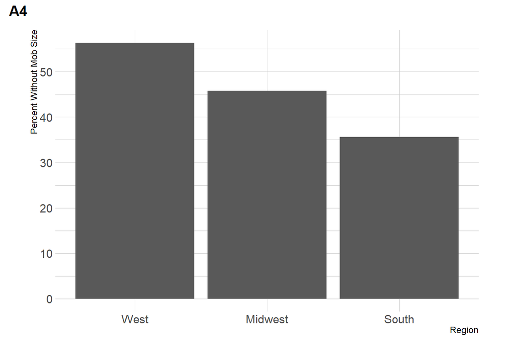

A5: Summary Statistics for Numeric Control Variables

| Variable | Minimum | Maximum | SD | M | Median |
| --- | --- | --- | --- | --- | --- |
| Democratic Vote | 0.000 | 1.000 | 0.241 | 0.473 | 0.418 |
| Percent Nonwhite | 0.000 | 0.911 | 0.206 | 0.142 | 0.027 |
| Percent Rural | 0.000 | 1.000 | 0.245 | 0.811 | 0.923 |
| Percent White Adults Illiterate | 0.000 | 0.544 | 0.054 | 0.053 | 0.035 |
| Population Density | 3.611 | 14.932 | 1.023 | 9.762 | 9.790 |

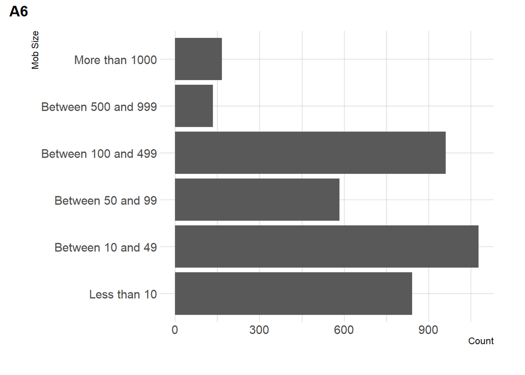

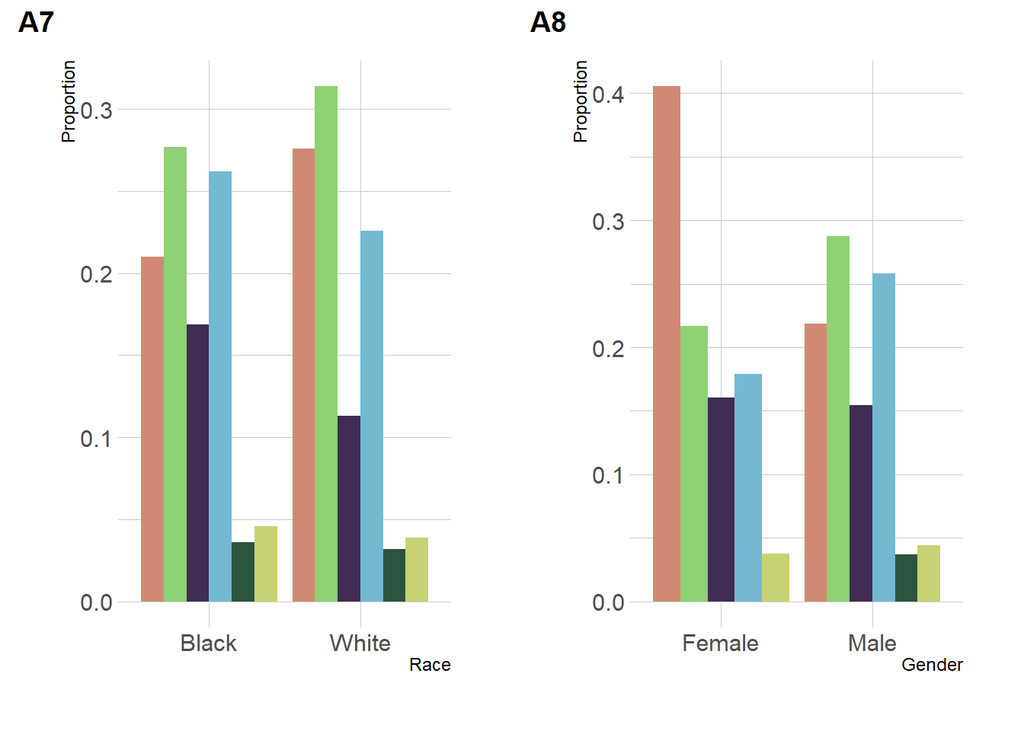

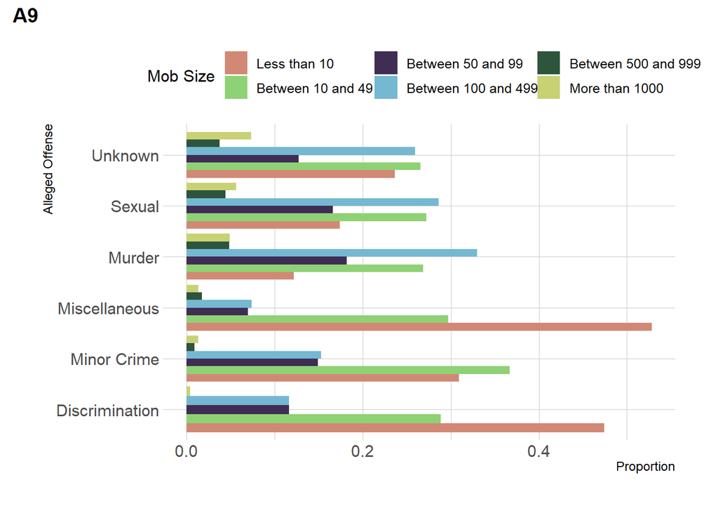

## Bibliography

“270 To Win - Historical Presidential Elections”. 2006. United States. [Web Archive] Retrieved from the Library of Congress, https://www.loc.gov/item/lcwaN0017872/.

*NAACP administrative file: Subject file.Lectures etc. – National Conference on Lynching, 1919.* (1980). (Vol. reel 26, fr. 1086-reel 28, fr. 0213.;reel 26, fr. 1086-reel 28, fr. -0213;). University Publications of America.

Bailey, A. K., & Tolnay, S. E. (2015) *Lynched : the victims of Southern mob violence*. University of North Carolina Press.

Beck, E. M., & Tolnay, S. E. (1990). The Killing Fields of the Deep South: The Market for Cotton and the Lynching of Blacks, 1882-1930. *American Sociological Review*, 55(4), 526-539. https://doi.org/10.2307/2095805

Blalock, H. M. (1967). *Toward a theory of minority-group relations* (Vol. 325). New York: Wiley.

Christian, C. (2017). Lynchings, labour, and cotton in the US south: A reappraisal of Tolnay and Beck. *Explorations in economic history*, 66, 106-116. https://doi.org/10.1016/j.eeh.2017.08.005

Cook, L. D., Logan, T. D., & Parman, J. M. (2018). Racial segregation and southern lynching. *Social science history*, 42(4), 635-675.

Corzine, J., Creech, J., & Corzine, L. (1983). Black Concentration and Lynchings in the South: Testing Blalock’s Power- Threat Hypothesis. Social forces, 61(3), 774-796. https://doi.org/10.1093/sf/61.3.774

Creech, J. C., Corzine, J., & Huff-Corzine, L. (1989). Theory Testing and Lynching: Another Look at the Power Threat Hypothesis. *Social forces*, 67(3), 626.

Frisken, A. K. (2012). “A Song Without Words”: Anti-Lynching Imagery in the African American Press, 1889–1898. *The Journal of African American history*, 97(3), 240-269. https://doi.org/10.5323/jafriamerhist.97.3.0240

Gonzales-Day, K. (2006). *Lynching in the West*, 1850-1935. Duke University Press.

Hagen, R., Makovi, K., & Bearman, P. (2013). The Influence of Political Dynamics on Southern Lynch Mob Formation and Lethality. *Social forces*, 92(2), 757-787. https://doi.org/10.1093/sf/sot093

Keil, T. J., & Vito, G. F. (2009). Lynching and the Death Penalty in Kentucky, 1866–1934: Substitution or Supplement? *Journal of Ethnicity in Criminal Justice*, 7(1), 53-68. https://doi.org/10.1080/15377930802711813

Labode, M. (2014). The “stern, fearless settlers of the West”: Lynching, Region, and Capital Punishment in Early Twentieth-Century Colorado. *The Western historical quarterly*, 45(4), 389-409. https://doi.org/10.2307/westhistquar.45.4.0389

Leader, T., Mullen, B., & Abrams, D. (2007). Without Mercy: The Immediate Impact of Group Size on Lynch Mob Atrocity. Personality & social psychology bulletin, 33(10), 1340-1352. https://doi.org/10.1177/0146167207303951

Pfeifer, M. J. e. (2017). *Global lynching and collective violence*. University of Illinois Press.

Price, G. N., Darity, W. A., & Headen, A. E. (2008). Does the stigma of slavery explain the maltreatment of blacks by whites?: The case of lynchings. *The Journal of socio-economics*, 37(1), 167-193. https://doi.org/10.1016/j.socec.2007.06.001

Ritchey, A. J., & Ruback, R. B. (2018). Predicting Lynching Atrocity: The Situational Norms of Lynchings in Georgia. *Personality & social psychology bulletin*, 44(5), 619-637. https://doi.org/10.1177/0146167217733075

Ritchey, A. J., & Ruback, R. B. (2018). Predicting Lynching Atrocity: The Situational Norms of Lynchings in Georgia. Personality & social psychology bulletin, 44(5), 619-637. https://doi.org/10.1177/0146167217733075

Seguin, C., & Rigby, D. (2019). National Crimes: A New National Data Set of Lynchings in the United States, 1883 to 1941. *Socius : sociological research for a dynamic world*, 5, 237802311984178. https://doi.org/10.1177/2378023119841780

Smångs, M. (2020). Race, Gender, and the Rape-Lynching Nexus in the US South, 1881-1930. *Social problems* (Berkeley, Calif.), 67(4), 616-636. https://doi.org/10.1093/socpro/spz035

Smångs, M. (2016). Interracial status competition and southern lynching, 1882-1930. *Ethnic and racial studies*, 39(10), 1849-1868. https://doi.org/10.1080/01419870.2015.1110610

Smångs, M. (2017). The lynching of African Americans in the U.S. South: A review of sociological and historical perspectives. *Sociology compass*, 11(8), e12500-n/a. https://doi.org/10.1111/soc4.12500

Smångs, M (2017) *Doing violence, making race : lynching and White racial group formation in the U.S. South, 1882-1930*.

Soule, S. A. (1992). Populism and black lynching in Georgia, 1890–1900. *Social forces*, 71(2), 431-449.

Subašić, E., Reynolds, K. J., & Turner, J. C. (2008). The Political Solidarity Model of Social Change: Dynamics of Self-Categorization in Intergroup Power Relations. *Personality and social psychology review*, 12(4), 330-352. https://doi.org/10.1177/1088868308323223

Thomas Walker, P. (1901, Dec 1901). The real Judge Lynch. *The Atlantic Monthly* (1857-1932), 88(000530), 731.

Tolnay, S. (2012). Quantitative Narrative Analysis—What It Can and Cannot Tell Us About Lynching.*Sociological methodology*, 42(1), 91-93. https://doi.org/10.1177/0081175012460855

Tolnay, S. E., & Beck, E. M. (1995). *A festival of violence : an analysis of Southern lynchings, 1882-1930*. University of Illinois Press.

Tolnay, S. E., & Beck, E. M. (2018). “Racialized Terrorism” in the American South: Do Completed Lynchings Tell an Accurate Story? *Social science history*, 42(4), 677-701. https://doi.org/10.1017/ssh.2018.22

Tolnay, S. E., Beck, E. M., & Massey, J. L. (1989). Black Lynchings - The Power Threat Hypothesis Revisted. *Social forces*, 67(3), 605-623. https://doi.org/10.2307/2579531

Tolnay, S. E., Beck, E. M., & Massey, J. L. (1992). Black Competition and White Vengeance: Legal Execution of Blacks as Social Control in the Cotton South, 1890 to 1929. *Social science quarterly*, 73(3), 627-644.

Tyson, T. B., (2017). *The blood of Emmett Till*. Simon & Schuster.

Wells, I. B. (1909). *Lynching, Our National Crime*.

Wright, S. C., Taylor, D. M., & Moghaddam, F. M. (1990). Responding to membership in a disadvantaged group : from acceptance to collective protest. *Journal of personality and social psychology*, 58(6), 994-1003. https://doi.org/10.1037//0022-3514.58.6.994